# SLML_hw4

凌浩东

10/23/2021

## 1

### (1)

From
$$\begin{align*}
p(x_i;\beta) = P(Y=1|X=x_i) = \frac{exp(x_i^T\beta)}{1+exp(x_i^T\beta)}
\end{align*}$$
we can derive that
$$log\left(\frac{p(x_i;\beta)}{1-p(x_i;\beta)}\right) = x_i^T\beta$$
Hence,
$$\begin{align*}
\mathcal{l}(\beta) &= \sum_{i = 1}^{N}\left\{y_ilog\,p(x_i;\beta)+(1-y_i)log(1-p(x_i;\beta))\right\} \\
&= \sum_{i = 1}^{N}\left\{y_i[log\,p(x_i;\beta) - log(1-p(x_i;\beta)))]+log(1-p(x_i;\beta))\right\}\\
&= \sum_{i = 1}^{N}\left\{y_ilog\left(\frac{p(x_i;\beta)}{1-p(x_i;\beta)}\right)+log(1-p(x_i;\beta))\right\}\\
& =\sum_{i = 1}^{N} \left\{y_ix_i^T\beta-log(1+exp(x_i^T\beta))\right\}
\end{align*}$$

### (2)

$$\begin{align*}
\frac{\partial l(\beta)}{\partial \beta} &= \sum_i \left((y_i - 1)x_i + \frac{1}{1+exp(x_i^T\beta)}x_i\right)\\
\frac{\partial^2 l(\beta)}{\partial \beta \partial \beta^T}
& = \sum_i \left(-\frac{exp(x_i^T\beta)x_ix_i^T}{(1+exp(x_i^T\beta))^2}\right)\\
& = -\sum_i x_ix_i^Tp(x_i;\beta)\{1-p(x_i;\beta)\}
\end{align*}$$

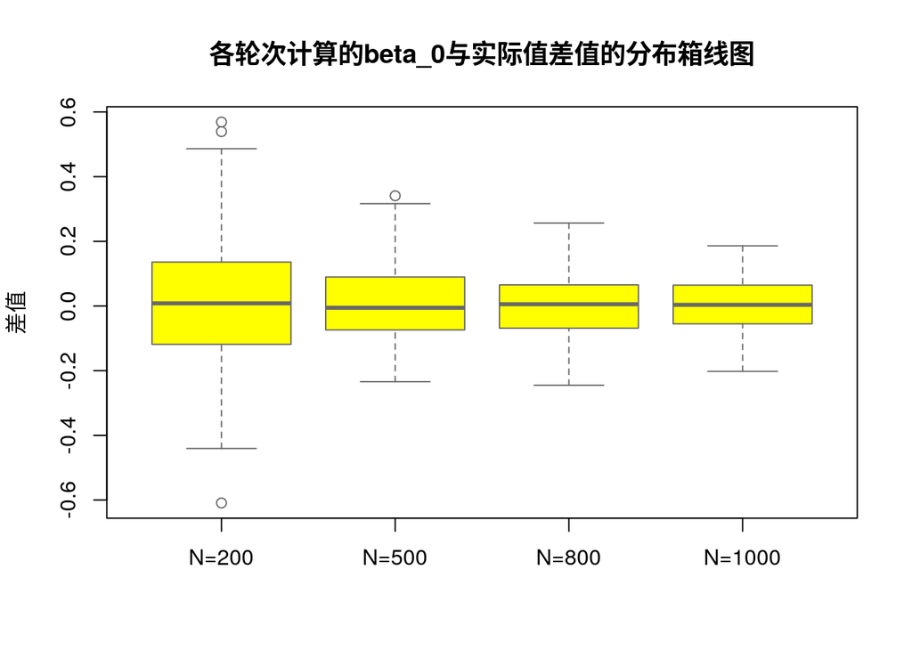

```r
NR <- function(N = 200) {
  result <- matrix(0, 3, 0)
  beta = matrix(c(0.5, 1.2, -1), 3, 1)
  for (R in 1:200) {
    x1 <- matrix(rnorm(N), N, 1)
    x2 <- matrix(rnorm(N), N, 1)
    x <- cbind(matrix(1, N, 1), x1, x2)
    prob <- exp(x%*%beta)/(1+exp(x%*%beta))
    y <- rbinom(N, size = 1, prob = prob)

    beta_old = c(-1, -1, -1)
        beta_new = c(0.5, 0.5, 0.5)
        while(max(abs(beta_old-beta_new)) > 1e-5) {
            p <- exp(x %*% beta_new)/(1+exp(x %*% beta_new))
            w <- diag(c(p*(1-p)))
            beta_old <- beta_new
            beta_new <- beta_old + solve(t(x)%*%w%*%x)%*%t(x)%*%(y-p)
        }
        result <- cbind(result, beta_new)
    }
    result
}

N <- c(200, 500, 800, 1000)
result1 <- NR(N[1])
result2 <- NR(N[2])
result3 <- NR(N[3])
result4 <- NR(N[4])

boxplot(result1[1,]-0.5, result2[1,]-0.5, result3[1,]-0.5, result4[1,]-0.5,
col="#ffff00", border="dimgray",
main="各轮次计算的beta_0与实际值差值的分布箱线图", ylab="差值",
names=c('N=200','N=500','N=800','N=1000'))
```

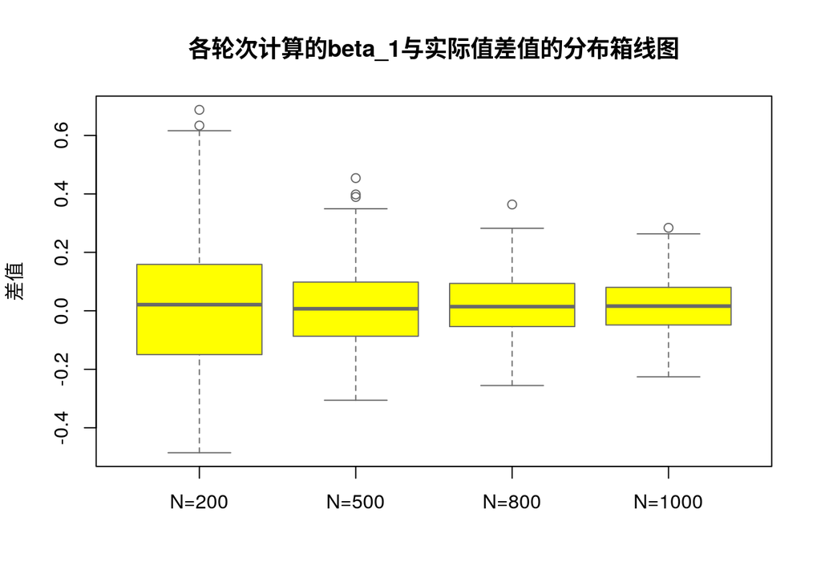

```r
boxplot(result1[2,]-1.2, result2[2,]-1.2, result3[2,]-1.2, result4[2,]-1.2,
col="#ffff00", border="dimgray",
main="各轮次计算的beta_1与实际值差值的分布箱线图", ylab="差值",
names=c('N=200','N=500','N=800','N=1000'))
```

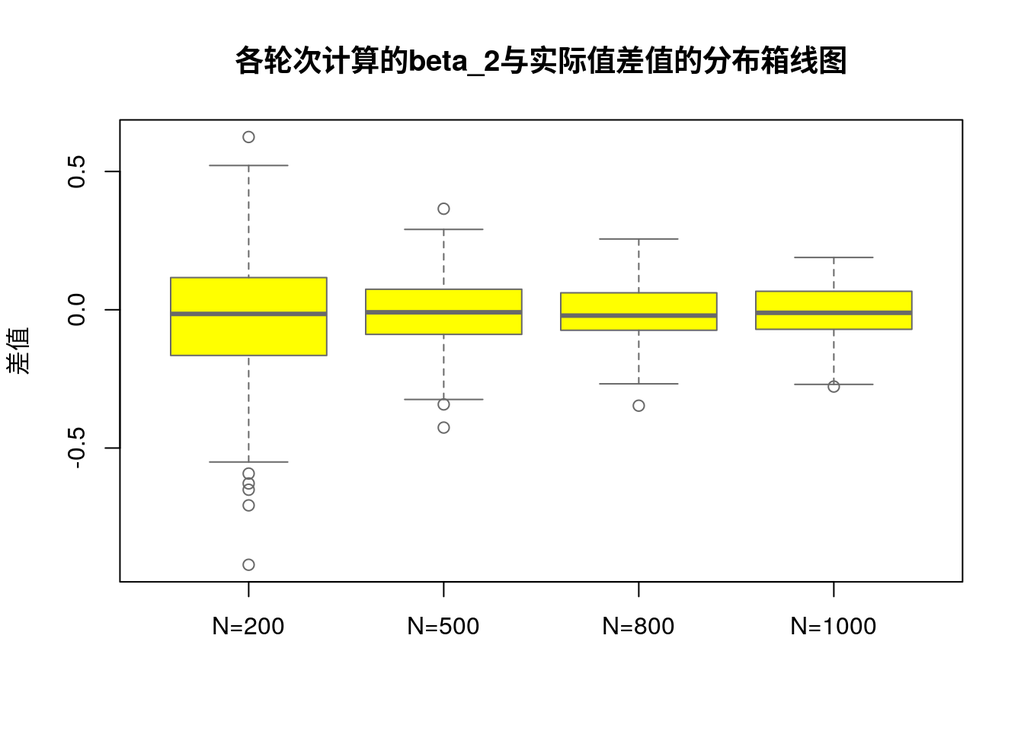

```r
boxplot(result1[3,]+1, result2[3,]+1, result3[3,]+1, result4[3,]+1,
col="#ffff00",border="dimgray",
main="各轮次计算的beta_2与实际值差值的分布箱线图", ylab="差值",
names=c('N=200','N=500','N=800','N=1000'))
```

### (3)

证明借鉴了[StackExchange](https://stats.stackexchange.com/questions/190216/why-is-roc-auc-equivalent-to-the-probability-that-two-randomly-selected-samples)

假设现在共n个样本点已经按照样本值从大到小排列， 即$f(x_1) > \cdots > f(x_n)$。 设置阈值$\tau \in {f(x_1), \cdots, f(x_n)}$， 记$\tau = f(x_i)$时的TPR和FPR分别为 $TPR_i$，$FPR_i$， 则
$$TPR_i = \frac{\sum_{k=1}^{i}I(y_k = 1)}{m^+}\\
FPR_i = \frac{\sum_{k=1}^{i}I(y_k = 0)}{m^-}$$
ROC图线下的面积为：
$$\begin{align*}
AUC &= \sum_{i=1}^{n-1}\frac{1}{2}(TPR_i+TPR_{i+1})(FPR_{i+1}-FPR_i)\\
&= \frac{1}{2m^+m^-}\sum_{i=1}^{n-1}\left(\sum_{k=1}^{i}I(y_k = 1)+\sum_{k=1}^{i+1}I(y_k = 1)\right)\left(\sum_{k=1}^{i+1}I(y_k = 0)-\sum_{k=1}^{i}I(y_k = 0)\right)\\
&= \frac{1}{2m^+m^-}\sum_{i=1}^{n-1}\left(2\sum_{k=1}^{i}I(y_k = 1)+I(y_{i+1} = 1)\right)I(y_{i+1} = 0)\\
*& = \frac{1}{m^+m^-}\sum_{i=1}^{n-1}\sum_{k=1}^{i}I(y_k = 1)I(y_{i+1} = 0)\\
&= \frac{1}{m^+m^-}\sum_{k<i+1}I(y_k > y_{i+1})\\
&= \frac{1}{m^+m^-}\sum_{x^+\in D^+}\sum_{x^-\in D^-}(I(f(x^+)>f(x^-)))
\end{align*}$$
带星号的等式成立的原因是$I(y_{i+1} = 1)I(y_{i+1} = 0)=0$。

下面对最后一个等式进行分析： $\sum_{k<i+1}I(y_k > y_{i+1})$的意思是， 对任意一对样本点， 若其中样本值较大的那一点是正例， 样本值较小的那一点是负例， 则对其进行计数。

$\sum_{x^+\in D^+}\sum_{x^-\in D^-}(I(f(x^+)>f(x^-)))$的意思是， 对任意一对正负样本， 若正样本的值大于负样本的值， 对其进行计数。

显然，这两者是相等的。

因此，
$$\begin{align*}
1-AUC &= 1- \frac{1}{m^+m^-}\sum_{x^+\in D^+}\sum_{x^-\in D^-}I(f(x^+)>f(x^-))\\
&= \frac{1}{m^+m^-}\sum_{x^+\in D^+}\sum_{x^-\in D^-}(1-I(f(x^+)>f(x^-)))\\
& = \frac{1}{m^+m^-}\sum_{x^+\in D^+}\sum_{x^-\in D^-}I(f(x^+)<f(x^-))\\
& = l_{rank}
\end{align*}$$

## 2 客户流失预警数据分析及算法实现

### 2.1 读入训练数据

```r
sampledata <- read.csv('sampledata.csv')
preddata <- read.csv('preddata.csv')
```

训练数据的初步统计结果如下：

```r
summary(sampledata) %>%
  kbl() %>%
  kable_styling()
```

|  | ID | tenure | expense | degree | tightness | entropy | chgexpense | chgdegree | churn |
| --- | --- | --- | --- | --- | --- | --- | --- | --- | --- |
|  | Min. : 1 | Min. : 184.0 | Min. : 0.1784 | Min. : 0.04722 | Min. : 0.00486 | Min. :0.000 | Min. :-1.00000 | Min. :-0.9964 | Min. :0.00000 |
|  | 1st Qu.:12096 | 1st Qu.: 537.1 | 1st Qu.: 98.2789 | 1st Qu.: 30.34109 | 1st Qu.: 5.41880 | 1st Qu.:2.373 | 1st Qu.:-0.07634 | 1st Qu.:-0.1573 | 1st Qu.:0.00000 |
|  | Median :24201 | Median : 994.7 | Median :136.0573 | Median : 54.12898 | Median : 8.03004 | Median :2.990 | Median : 0.00000 | Median : 0.0000 | Median :0.00000 |
|  | Mean :24198 | Mean :1257.5 | Mean :161.2421 | Mean : 66.68942 | Mean : 9.86537 | Mean :2.931 | Mean : 0.00762 | Mean : 0.0376 | Mean :0.01247 |
|  | 3rd Qu.:36299 | 3rd Qu.:1635.9 | 3rd Qu.:204.0966 | 3rd Qu.: 89.85727 | 3rd Qu.:11.94831 | 3rd Qu.:3.559 | 3rd Qu.: 0.04337 | 3rd Qu.: 0.1667 | 3rd Qu.:0.00000 |
|  | Max. :48393 | Max. :4479.6 | Max. :511.0550 | Max. :303.98270 | Max. :61.67615 | Max. :5.346 | Max. : 2.66502 | Max. : 7.3333 | Max. :1.00000 |

### 2.2 绘制因变量和各个自变量的箱线图

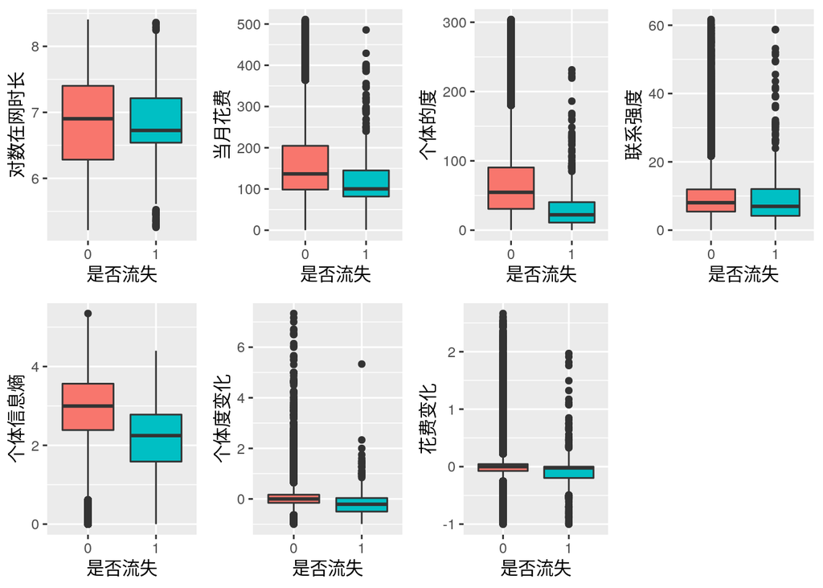

```r
p1 <- ggplot(sampledata, aes(x = as.factor(churn), y = log(tenure), fill = as.factor(churn)))  + geom_boxplot() + theme(legend.position="none") +
  xlab('是否流失') + ylab('对数在网时长')
p2 <- ggplot(sampledata, aes(x = as.factor(churn), y = expense, fill = as.factor(churn)))  + geom_boxplot() + theme(legend.position="none") +
  xlab('是否流失') + ylab('当月花费')
p3 <- ggplot(sampledata, aes(x = as.factor(churn), y = degree, fill = as.factor(churn)))  + geom_boxplot() + theme(legend.position="none") +
  xlab('是否流失') + ylab('个体的度')
p4 <- ggplot(sampledata, aes(x = as.factor(churn), y = tightness, fill = as.factor(churn)))  + geom_boxplot() + theme(legend.position="none") +
  xlab('是否流失') + ylab('联系强度')
p5 <- ggplot(sampledata, aes(x = as.factor(churn), y = entropy, fill = as.factor(churn)))  + geom_boxplot() + theme(legend.position="none") +
  xlab('是否流失') + ylab('个体信息熵')
p6 <- ggplot(sampledata, aes(x = as.factor(churn), y = chgdegree, fill = as.factor(churn)))  + geom_boxplot() + theme(legend.position="none") +
  xlab('是否流失') + ylab('个体度变化')
p7 <- ggplot(sampledata, aes(x = as.factor(churn), y = chgexpense, fill = as.factor(churn)))  + geom_boxplot() + theme(legend.position="none") +
  xlab('是否流失') + ylab('花费变化')

grid.arrange(p1,p2,p3,p4,p5,p6,p7, nrow=2)
```

### 2.3 建立逻辑回归模型

```r
traindata <- sampledata
traindata[2:8] <- scale(traindata[2:8]) # 对自变量进行标准化
lr <- glm(churn~tenure+expense+degree+tightness+entropy+chgexpense+chgdegree, family = binomial(link=logit), data = traindata)
summary(lr)
```

```
##
## Call:
## glm(formula = churn ~ tenure + expense + degree + tightness +
##     entropy + chgexpense + chgdegree, family = binomial(link = logit),
##     data = traindata)
##
## Deviance Residuals:
##     Min       1Q   Median       3Q      Max
## -0.8909  -0.1748  -0.1198  -0.0748   4.2072
##
## Coefficients:
##             Estimate Std. Error z value Pr(>|z|)
## (Intercept) -5.05338    0.07212 -70.067  < 2e-16 ***
## tenure      -0.24767    0.06070  -4.080 4.50e-05 ***
## expense     -0.29229    0.05904  -4.951 7.39e-07 ***
## degree      -0.73751    0.13172  -5.599 2.15e-08 ***
## tightness   -0.22660    0.04254  -5.327 9.99e-08 ***
## entropy     -0.35176    0.07208  -4.880 1.06e-06 ***
## chgexpense  -0.16071    0.04893  -3.284  0.00102 **
## chgdegree   -0.38279    0.05208  -7.349 1.99e-13 ***
## ---
## Signif. codes:  0 '***' 0.001 '**' 0.01 '*' 0.05 '.' 0.1 ' ' 1
##
## (Dispersion parameter for binomial family taken to be 1)
##
##     Null deviance: 6475.5  on 48284  degrees of freedom
## Residual deviance: 5757.6  on 48277  degrees of freedom
## AIC: 5773.6
##
## Number of Fisher Scoring iterations: 8
```

```r
exp(lr$coefficients)
```

```
## (Intercept)      tenure     expense      degree   tightness     entropy
##  0.00638773  0.78061519  0.74655043  0.47830395  0.79724311  0.70345100
##  chgexpense   chgdegree
##  0.85153640  0.68195330
```

一个事件的几率（odds）是指事件发生的概率 与事件不发生概率的比值。 在本案例中，几率指的是客户流失与客户不流失的概率比值，且
$$odds = \frac{p}{1-p} = e^{\beta^Tx}$$

```r
sapply(sampledata[2:8], sd)
```

```
##      tenure     expense      degree   tightness     entropy  chgexpense
## 966.0292780  89.5542799  49.1250498   7.1390448   0.8579744   0.2727523
##   chgdegree
##   0.3862277
```

### 2.4 对训练集和测试集进行预测

阈值为0.5时， 对训练集和测试集的预测结果如下：

```r
train_hat <- predict.glm(lr, newdata = traindata, type = 'response')
train_pred1 <- 1*(train_hat > 0.5)
table(train_pred1, traindata$churn)
```

```
##
## train_pred1     0     1
##           0 47683   602
```

```r
testdata <- preddata
testdata[2:8] <- scale(testdata[2:8])
test_hat <- predict.glm(lr, newdata = testdata, type = 'response')
test_pred1 <- 1*(test_hat > 0.5)
table(test_pred1, testdata$churn)
```

```
##
## test_pred1     0     1
##          0 47111   660
```

阈值为平均值时， 对训练集和测试集的预测结果如下：

```r
train_pred2 <- 1*(train_hat > mean(traindata$churn))
table(train_pred2, traindata$churn)
```

```
##
## train_pred2     0     1
##           0 32591   171
##           1 15092   431
```

```r
test_pred <- 1*(test_hat > mean(testdata$churn))
table(test_pred, testdata$churn)
```

```
##
## test_pred     0     1
##         0 33843   201
##         1 13268   459
```

### 2.5 绘制训练集和测试集上预测结果的ROC曲线

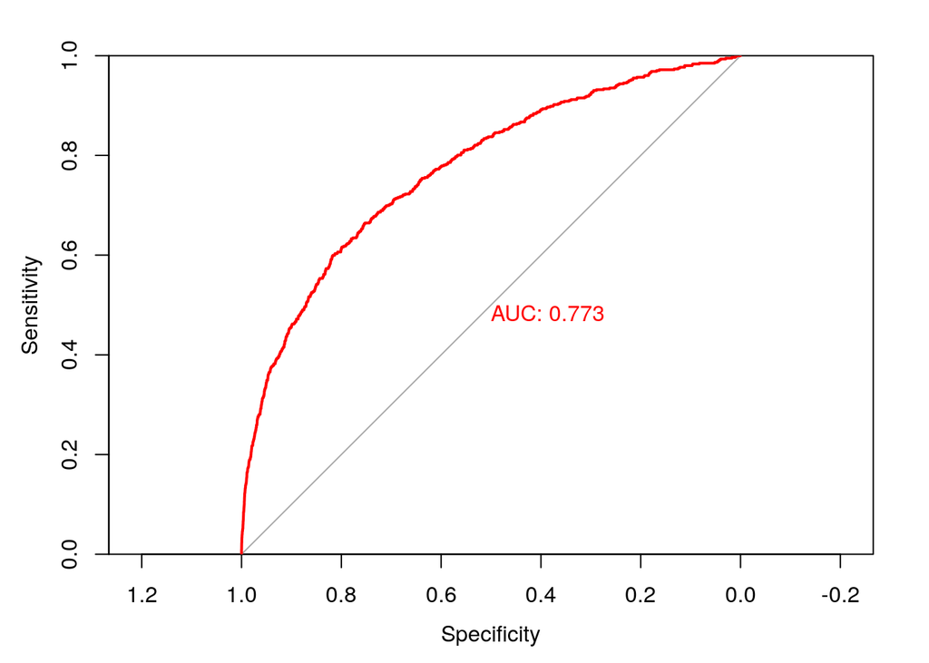

```r
plot.roc(traindata$churn, train_hat, col = 'red', lwd = 2, xaxs = 'i', yaxs = 'i', print.auc = T)
```

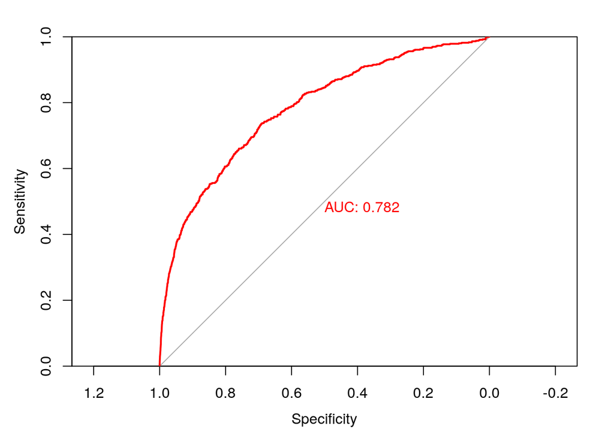

```r
plot.roc(testdata$churn, test_hat, col = 'red', lwd = 2, xaxs = 'i', yaxs = 'i', print.auc=T)
```

模型在训练集和测试集上的AUC分别为 0.773和0.782，证明模型的泛化能力较强。